# Health Data Science

# 3 Contingency Tables

## 3.1 Smoking

### 3.1.1 Smoking and Diseases

```r
# contingency tables and chisquared test for
# ADSMOK42


#starting with ADSMOK42 and physical health

titles_health_disease <- c(
  ASTHDX = "Asthma Diagnosis",
  ARTHDX = "Arthritis Diagnosis",
  CALUNG = "Lung Cancer Diagnosis",
  CHOLDX = "Cholesterol Diagnosis",
  CHBRON31 = "Chronic Bronchitis Diagnosis",
  DIABDX_M18 = "Diabetes Diagnosis",
  EMPHDX = "Emphysema Diagnosis",
  HIBPDX = "High Blood Pressure Diagnosis",
  STRKDX = "Stroke Diagnosis"
)

for(variable in health_disease_variables){
  if("1 YES" %in% levels(small_df[[variable]])){
  print(titles_health_disease[variable])
  print("Contingency table")
  print(cont_tables(small_df, "ADSMOK42", variable)%>% round(digits=3))
  print("testing hypothesis of no association")
  print(cont_tables(small_df, "ADSMOK42", variable,F)%>% chisq.test(correct = F))
  print("------------")
  }

}
```

```
##             ASTHDX
## "Asthma Diagnosis"
## [1] "Contingency table"
```

```
##         ASTHDX
## ADSMOK42 1 YES  2 NO
##    1 YES 0.176 0.824
##    2 NO  0.146 0.854
## [1] "testing hypothesis of no association"
##
##  Pearson's Chi-squared test
##
## data:  .
## X-squared = 15.62, df = 1, p-value = 7.743e-05
##
## [1] "------------"
##                ARTHDX
## "Arthritis Diagnosis"
## [1] "Contingency table"
##         ARTHDX
## ADSMOK42 1 YES  2 NO
##    1 YES 0.355 0.645
##    2 NO  0.329 0.671
## [1] "testing hypothesis of no association"
##
##  Pearson's Chi-squared test
##
## data:  .
## X-squared = 6.784, df = 1, p-value = 0.009198
##
## [1] "------------"
##                  CALUNG
## "Lung Cancer Diagnosis"
## [1] "Contingency table"
##         CALUNG
## ADSMOK42 1 YES  2 NO
##    1 YES 0.044 0.956
##    2 NO  0.025 0.975
## [1] "testing hypothesis of no association"
##
##  Pearson's Chi-squared test
##
## data:  .
## X-squared = 3.6873, df = 1, p-value = 0.05483
```

[output cut: 77 more lines]

```
##             STRKDX
## "Stroke Diagnosis"
## [1] "Contingency table"
##         STRKDX
## ADSMOK42 1 YES  2 NO
##    1 YES 0.076 0.924
##    2 NO  0.050 0.950
## [1] "testing hypothesis of no association"
##
##  Pearson's Chi-squared test
##
## data:  .
## X-squared = 29.652, df = 1, p-value = 5.169e-08
##
## [1] "------------"
```

Summary of findings from contingency tables:

Asthma diagnosis: the association is statistically significant

Arthritis: also statistically significant

Lung cancer: p-value is just above 5%, the significance is weaker

Cholesterol Diagnosis: Smokers do have higher rates than non-smokers, but it’s not statistically significant

Chronic Bronchitis: the association is statistically significant

Diabetes diagnosis: also statistically significant

Emphysema diagnosis: also statistically significant

High blood pressure: also statistically significant

Stroke diagnosis: also statistically significant

All the findings are promising: the contingency tables show strong association between smoking and various diseases. However this is not enough to draw conclusions: we need to control for other variables. We know that the percentage of smokers is different for different age brackets, now we will repeat the test but only selecting one age bracket at the time

```r
chisq_df_diseases = data.frame(diseases = health_disease_variables,
                               p_val_full_data= rep(NA, length(health_disease_variables)),
                               p_val_65plus_data= rep(NA, length(health_disease_variables)),
                               p_val_45_64_data= rep(NA, length(health_disease_variables)))

for(i in 1:nrow(chisq_df_diseases)){
  variable = chisq_df_diseases[i,"diseases"]
  test_full = cont_tables(small_df,"ADSMOK42",variable, F) %>%
    chisq.test(correct = F)
  test_45_64 = cont_tables_age(small_df,"ADSMOK42",variable,"45-64",F) %>%
    chisq.test(correct = F)
  test_65plus = cont_tables_age(small_df,"ADSMOK42",variable,"65+",F) %>%
    chisq.test(correct = F)
  chisq_df_diseases[i,"p_val_full_data"] = test_full$p.val
  chisq_df_diseases[i,"p_val_45_64_data"] = test_45_64$p.val
  chisq_df_diseases[i,"p_val_65plus_data"] = test_65plus$p.val
}
```

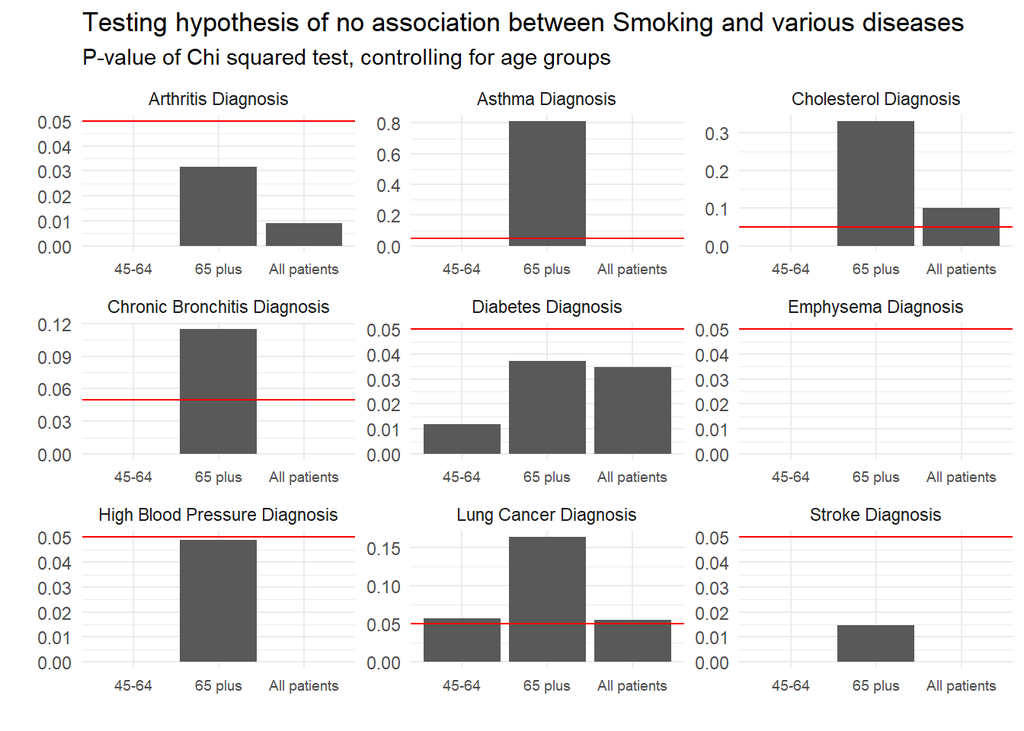

```r
chisq_df_diseases = chisq_df_diseases %>%
  mutate(diseases = titles_health_disease[diseases]) %>%
  pivot_longer(cols=c("p_val_full_data","p_val_65plus_data","p_val_45_64_data"))

ggplot(chisq_df_diseases, aes(x = name, y = value)) +
  geom_col() + geom_hline(aes(yintercept = 0.05), col = "red") +
  facet_wrap(~diseases, scales = "free") +
  labs(title="Testing hypothesis of no association between Smoking and various diseases",
       subtitle = "P-value of Chi squared test, controlling for age groups",
       x = "", y ="")+
  scale_x_discrete(labels = c("p_val_full_data" = "All patients",
                              "p_val_65plus_data" = "65 plus",
                              "p_val_45_64_data" = "45-64")) +
  theme_minimal() + theme(axis.text.x = element_text(size = 7))
```

We can also look at the odds ratio.

```r
or_data_all = expand.grid(diseases = health_disease_variables,
                      age = "all",estimate = NA,
                      lower = NA, upper = NA)

for(i in 1:nrow(or_data_all)){
  var_of_interest = as.character(or_data_all$diseases[i])
  or = small_df %>%
    select(ADSMOK42,var_of_interest)%>%
    filter(ADSMOK42 %in% c("1 YES", "2 NO"),
           .data[[var_of_interest]] %in% c("1 YES", "2 NO")) %>%
    mutate(across(c(1,2), factor)) %>%
    table() %>% epitools::oddsratio(method = "wald", correction = F)
  or_data_all[i,"estimate"] = or$measure[2,"estimate"]
  or_data_all[i,"lower"] = or$measure[2,"lower"]
  or_data_all[i,"upper"] = or$measure[2,"upper"]
}

or_data_45_64 = expand.grid(diseases = health_disease_variables,
                      age = "45_64",estimate = NA,
                      lower = NA, upper = NA)

for(i in 1:nrow(or_data_45_64)){
  var_of_interest = as.character(or_data_45_64$diseases[i])
  or = small_df %>% filter(age_group == "45-64") %>%
    select(ADSMOK42,var_of_interest)%>%
    filter(ADSMOK42 %in% c("1 YES", "2 NO"),
           .data[[var_of_interest]] %in% c("1 YES", "2 NO")) %>%
    mutate(across(c(1,2), factor)) %>%
    table() %>% epitools::oddsratio(method = "wald", correction = F)
  or_data_45_64[i,"estimate"] = or$measure[2,"estimate"]
  or_data_45_64[i,"lower"] = or$measure[2,"lower"]
  or_data_45_64[i,"upper"] = or$measure[2,"upper"]
}
```

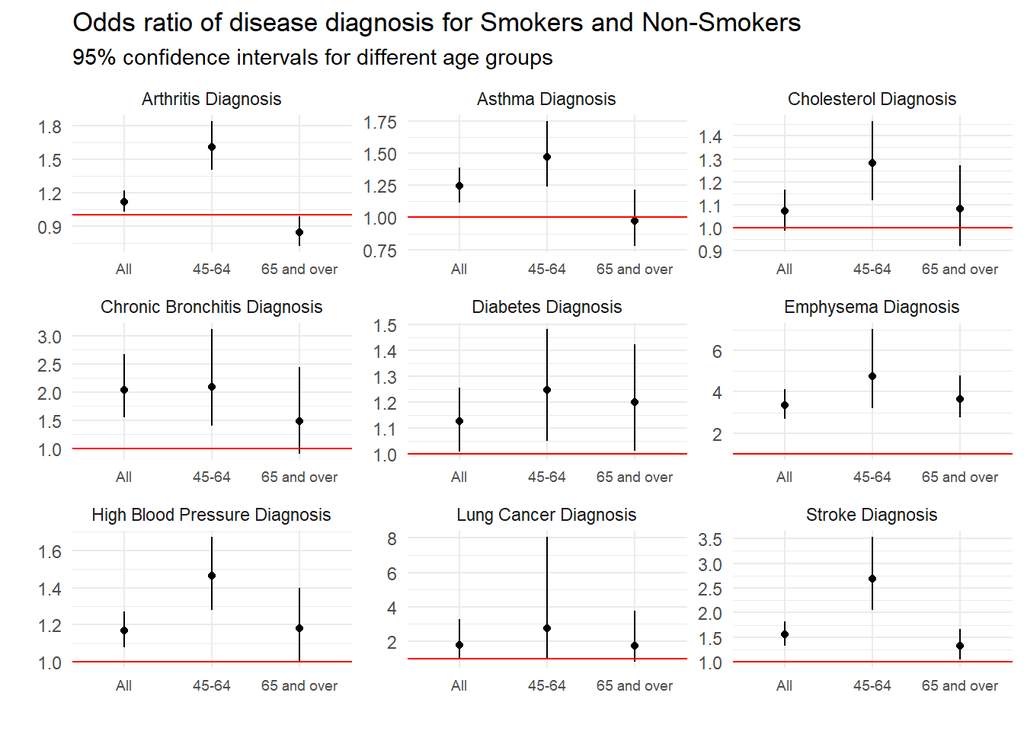

```r
or_data_65plus = expand.grid(diseases = health_disease_variables,
                      age = "65plus",estimate = NA,
                      lower = NA, upper = NA)

for(i in 1:nrow(or_data_65plus)){
  var_of_interest = as.character(or_data_65plus$diseases[i])
  or = small_df %>% filter(age_group == "65+") %>%
    select(ADSMOK42,var_of_interest)%>%
    filter(ADSMOK42 %in% c("1 YES", "2 NO"),
           .data[[var_of_interest]] %in% c("1 YES", "2 NO")) %>%
    mutate(across(c(1,2), factor)) %>%
    table() %>% epitools::oddsratio(method = "wald", correction = F)
  or_data_65plus[i,"estimate"] = or$measure[2,"estimate"]
  or_data_65plus[i,"lower"] = or$measure[2,"lower"]
  or_data_65plus[i,"upper"] = or$measure[2,"upper"]
}

or_data = rbind(or_data_all,or_data_45_64,or_data_65plus)

or_data %>% mutate(diseases = titles_health_disease[diseases]) %>%
  ggplot(aes(x = age)) + geom_point(aes(y = estimate)) +
  geom_segment(aes(x = age, xend = age, y = lower, yend = upper))+
  geom_hline(aes(yintercept  = 1), col = "red")+
  facet_wrap(~diseases, scales = "free") +
  labs(title="Odds ratio of disease diagnosis for Smokers and Non-Smokers",
       subtitle = "95% confidence intervals for different age groups",
       x = "", y ="")+
  scale_x_discrete(labels = c("all" = "All",
                              "65plus" = "65 and over" ,
                              "45_64" = "45-64")) +
  theme_minimal() + theme(axis.text.x = element_text(size = 7))
```

### 3.1.2 Smoking and Mental Health

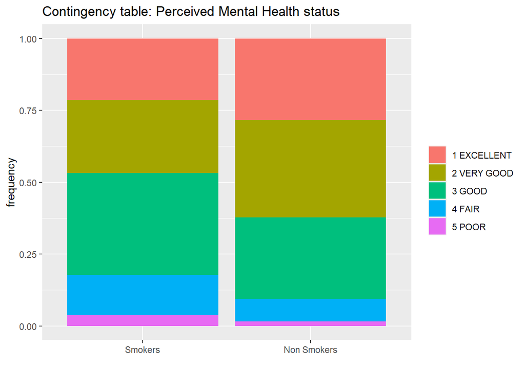

```r
#writing functions to make contingency tables for multiple categories

table_multi_cat = function(data, explanatory_var, var_of_interest, cond_prob = T){
  tbl = data %>%
    select(explanatory_var, var_of_interest)%>%
    filter(.data[[explanatory_var]] %in% c("1 YES", "2 NO"),
           !.data[[var_of_interest]] %in% c("-15 CANNOT BE COMPUTED",
                                            "-1 INAPPLICABLE",
                                            "-8 DK","-7 REFUSED"))%>%
    mutate(across(c(1,2), factor)) %>%
    table()
  if (cond_prob){
    tbl = tbl %>% prop.table(margin = 1)
  }
  tbl
}

#this one takes two variables and an age group, allowing to check separately
#different ages
table_multi_cat_age = function(data, explanatory_var, var_of_interest,
                           age_bracket, cond_prob = T){
  tbl = data %>% filter(age_group == age_bracket) %>%
    select(explanatory_var,var_of_interest) %>%
    filter(.data[[explanatory_var]] %in% c("1 YES", "2 NO"),
           !.data[[var_of_interest]] %in% c("-15 CANNOT BE COMPUTED",
                                            "-1 INAPPLICABLE",
                                            "-8 DK","-7 REFUSED"))%>%
    mutate(across(c(1,2), factor)) %>%
    table()

  if(cond_prob){
    tbl = tbl %>% prop.table(margin = 1)
    }
  tbl
}

#plotting all the mental health variables

# "MNHLTH31"
table_multi_cat(small_df, "ADSMOK42", "MNHLTH31") %>% as_tibble() %>%
  ggplot() + geom_col(aes(x = ADSMOK42, y = n, fill = MNHLTH31)) +
  labs(title = "Contingency table: Perceived Mental Health status", x = "",
       y="frequency", fill="") +
  scale_x_discrete(labels = c("1 YES" = "Smokers",
                              "2 NO" = "Non Smokers"))
```

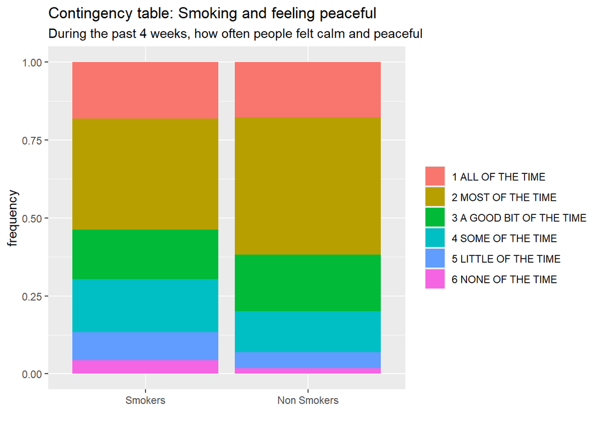

```r
#"ADPCFL42"
table_multi_cat(small_df, "ADSMOK42", "ADPCFL42") %>% as_tibble() %>%
  ggplot() + geom_col(aes(x = ADSMOK42, y = n, fill = ADPCFL42)) +
  labs(subtitle = "During the past 4 weeks, how often people felt calm and peaceful",
       title = "Contingency table: Smoking and feeling peaceful", x = "",
       y="frequency", fill="") +
  scale_x_discrete(labels = c("1 YES" = "Smokers",
                              "2 NO" = "Non Smokers"))
```

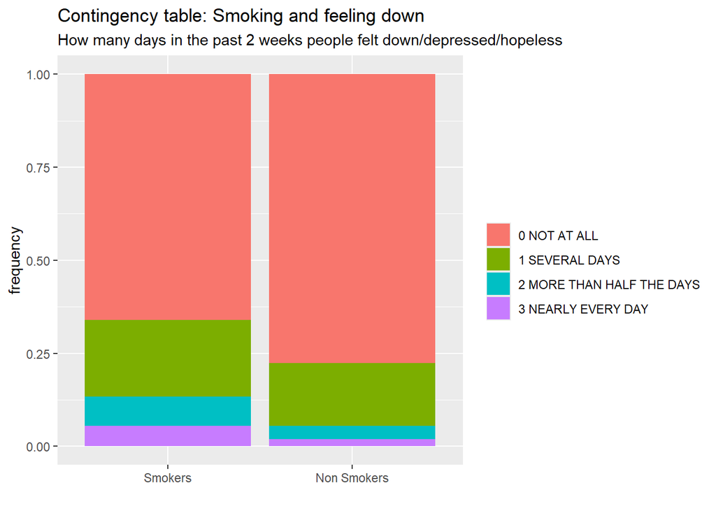

```r
#"ADDPRS42"
table_multi_cat(small_df, "ADSMOK42", "ADDPRS42") %>% as_tibble() %>%
  ggplot() + geom_col(aes(x = ADSMOK42, y = n, fill = ADDPRS42)) +
  labs(subtitle = "How many days in the past 2 weeks people felt down/depressed/hopeless",
       title = "Contingency table: Smoking and feeling down", x = "",
       y="frequency", fill="") +
  scale_x_discrete(labels = c("1 YES" = "Smokers",
                              "2 NO" = "Non Smokers"))
```

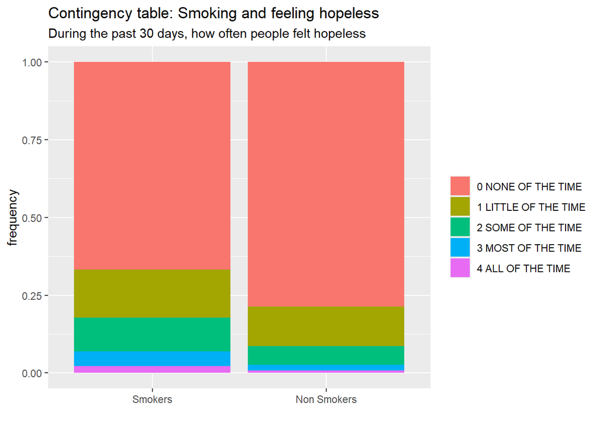

```r
# "ADHOPE42"
table_multi_cat(small_df, "ADSMOK42", "ADHOPE42") %>% as_tibble() %>%
  ggplot() + geom_col(aes(x = ADSMOK42, y = n, fill = ADHOPE42)) +
  labs(subtitle = "During the past 30 days, how often people felt hopeless",
       title = "Contingency table: Smoking and feeling hopeless", x = "",
       y="frequency", fill="") +
  scale_x_discrete(labels = c("1 YES" = "Smokers",
                              "2 NO" = "Non Smokers"))
```

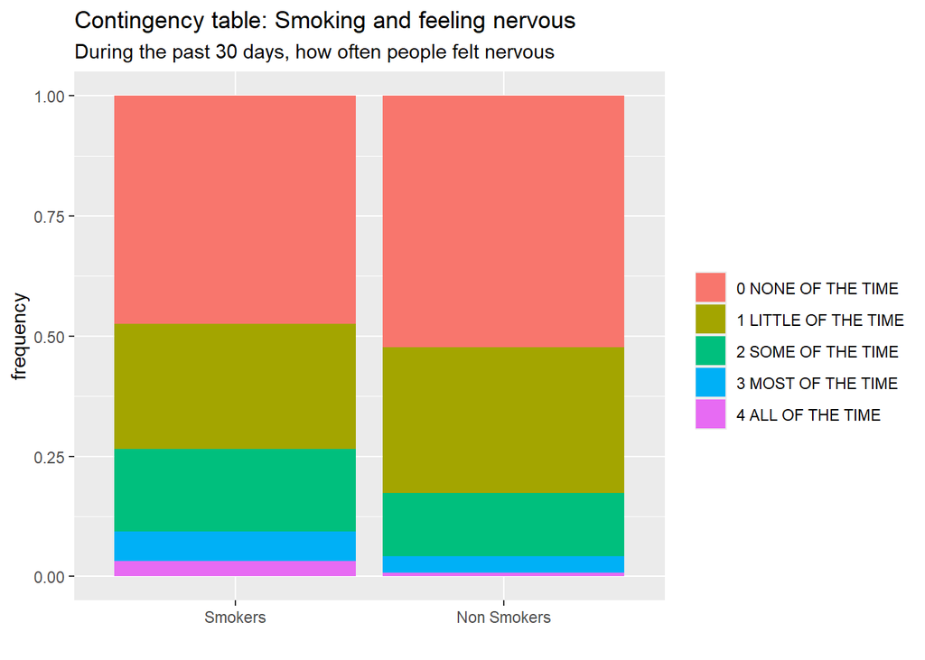

```r
# "ADNERV42"
table_multi_cat(small_df, "ADSMOK42", "ADNERV42") %>% as_tibble() %>%
  ggplot() + geom_col(aes(x = ADSMOK42, y = n, fill = ADNERV42)) +
  labs(subtitle = "During the past 30 days, how often people felt nervous",
       title = "Contingency table: Smoking and feeling nervous", x = "",
       y="frequency", fill="") +
  scale_x_discrete(labels = c("1 YES" = "Smokers",
                              "2 NO" = "Non Smokers"))
```

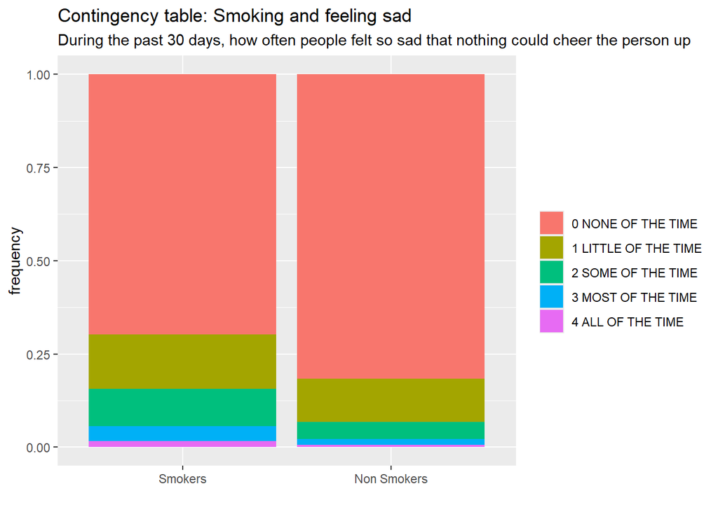

```r
# "ADSAD42"
table_multi_cat(small_df, "ADSMOK42", "ADSAD42") %>% as_tibble() %>%
  ggplot() + geom_col(aes(x = ADSMOK42, y = n, fill = ADSAD42)) +
  labs(subtitle = "During the past 30 days, how often people felt so sad that nothing could cheer the person up",
       title = "Contingency table: Smoking and feeling sad", x = "",
       y="frequency", fill="") +
  scale_x_discrete(labels = c("1 YES" = "Smokers",
                              "2 NO" = "Non Smokers"))
```

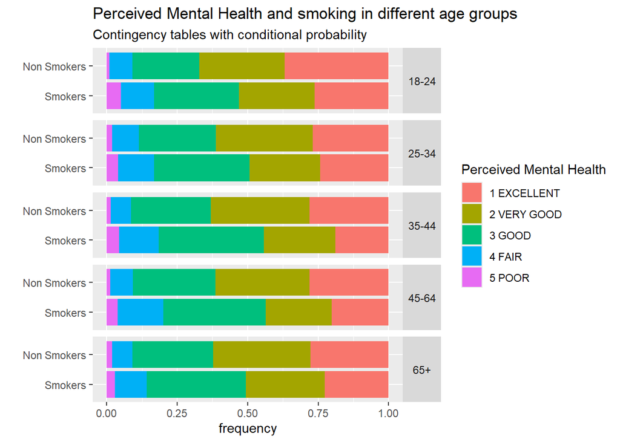

```r
# looking at how the contingency table for perceived mental health and smoking
# is different in the different age groups
age_18_24 = table_multi_cat_age(small_df, "ADSMOK42", "MNHLTH31", "18-24") %>% as_tibble %>%
  mutate(age = "18-24")
age_25_34 = table_multi_cat_age(small_df, "ADSMOK42", "MNHLTH31", "25-34") %>% as_tibble %>%
  mutate(age = "25-34")
age_35_44 = table_multi_cat_age(small_df, "ADSMOK42", "MNHLTH31", "35-44") %>% as_tibble %>%
  mutate(age = "35-44")
age_45_64 = table_multi_cat_age(small_df, "ADSMOK42", "MNHLTH31", "45-64") %>% as_tibble %>%
  mutate(age = "45-64")
age_65plus = table_multi_cat_age(small_df, "ADSMOK42", "MNHLTH31", "65+") %>% as_tibble %>%
  mutate(age = "65+")

all_tables = rbind(age_18_24,age_25_34,age_35_44,age_45_64,age_65plus)

all_tables %>% mutate(age = factor(age)) %>%
  ggplot(aes(x = n, fill = MNHLTH31, y = ADSMOK42)) +
  geom_col(orientation = "y") +
  facet_grid(rows = vars(age))+
  labs(title = "Perceived Mental Health and smoking in different age groups", y = "",
       subtitle = "Contingency tables with conditional probability", x="frequency", fill="Perceived Mental Health") +
  scale_y_discrete(labels = c("1 YES" = "Smokers",
                              "2 NO" = "Non Smokers"))+
  theme(strip.text.y = element_text(angle = 0))
```

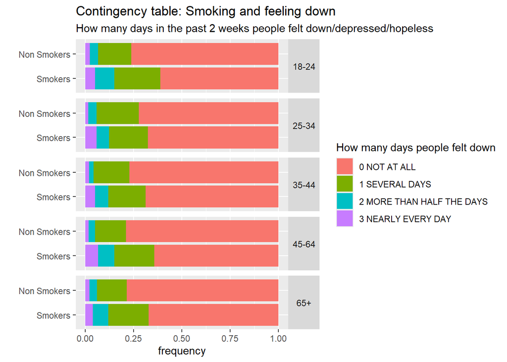

```r
# looking at how the contingency table for "ADDPRS42" and smoking
# is different in the different age groups
age_18_24 = table_multi_cat_age(small_df, "ADSMOK42", "ADDPRS42", "18-24") %>% as_tibble %>%
  mutate(age = "18-24")
age_25_34 = table_multi_cat_age(small_df, "ADSMOK42", "ADDPRS42", "25-34") %>% as_tibble %>%
  mutate(age = "25-34")
age_35_44 = table_multi_cat_age(small_df, "ADSMOK42", "ADDPRS42", "35-44") %>% as_tibble %>%
  mutate(age = "35-44")
age_45_64 = table_multi_cat_age(small_df, "ADSMOK42", "ADDPRS42", "45-64") %>% as_tibble %>%
  mutate(age = "45-64")
age_65plus = table_multi_cat_age(small_df, "ADSMOK42", "ADDPRS42", "65+") %>% as_tibble %>%
  mutate(age = "65+")

all_tables = rbind(age_18_24,age_25_34,age_35_44,age_45_64,age_65plus)

all_tables %>% mutate(age = factor(age)) %>%
  ggplot(aes(x = n, fill = ADDPRS42, y = ADSMOK42)) +
  geom_col(orientation = "y") +
  facet_grid(rows = vars(age))+
  labs(subtitle = "How many days in the past 2 weeks people felt down/depressed/hopeless",
       y = "", fill="How many days people felt down",
       title = "Contingency table: Smoking and feeling down", x="frequency", ) +
  scale_y_discrete(labels = c("1 YES" = "Smokers",
                              "2 NO" = "Non Smokers"))+
  theme(strip.text.y = element_text(angle = 0))
```

In general, we can say that the mental health of non-smokers is better across all indicators, and age doesn’t seem to have any impact on this. This is expected, because old age is not associated with worse mental health as strongly as it is associated with physical and general health.

### 3.1.3 General Health and Smoking

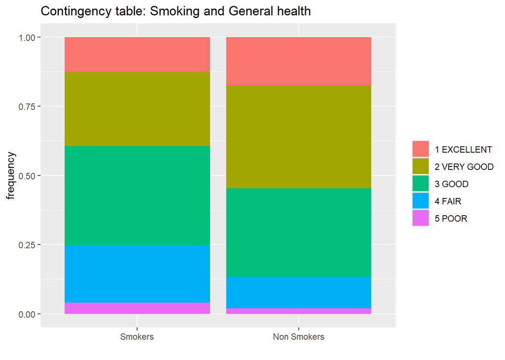

```r
#ADGENH42
table_multi_cat(small_df, "ADSMOK42", "ADGENH42") %>% as_tibble() %>%
  ggplot() + geom_col(aes(x = ADSMOK42, y = n, fill = ADGENH42)) +
  labs(title = "Contingency table: Smoking and General health", x = "",
       y="frequency", fill="") +
  scale_x_discrete(labels = c("1 YES" = "Smokers",
                              "2 NO" = "Non Smokers"))
```

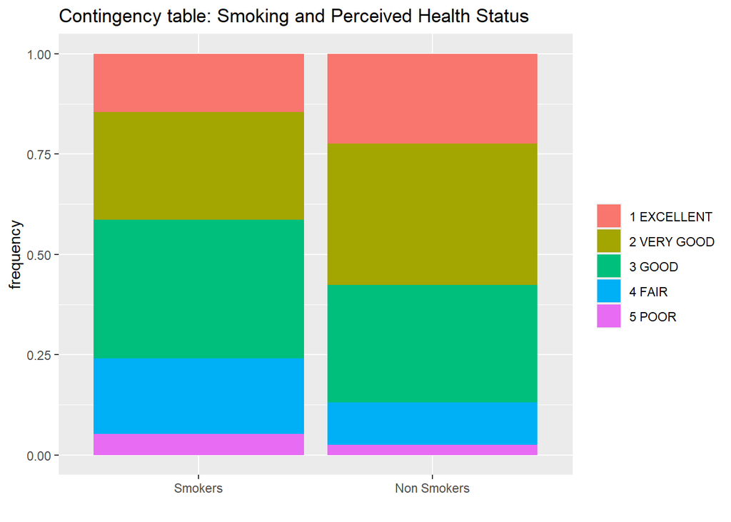

```r
#RTHLTH31
table_multi_cat(small_df, "ADSMOK42", "RTHLTH31") %>% as_tibble() %>%
  ggplot() + geom_col(aes(x = ADSMOK42, y = n, fill = RTHLTH31)) +
  labs(title = "Contingency table: Smoking and Perceived Health Status", x = "",
       y="frequency", fill="") +
  scale_x_discrete(labels = c("1 YES" = "Smokers",
                              "2 NO" = "Non Smokers"))
```

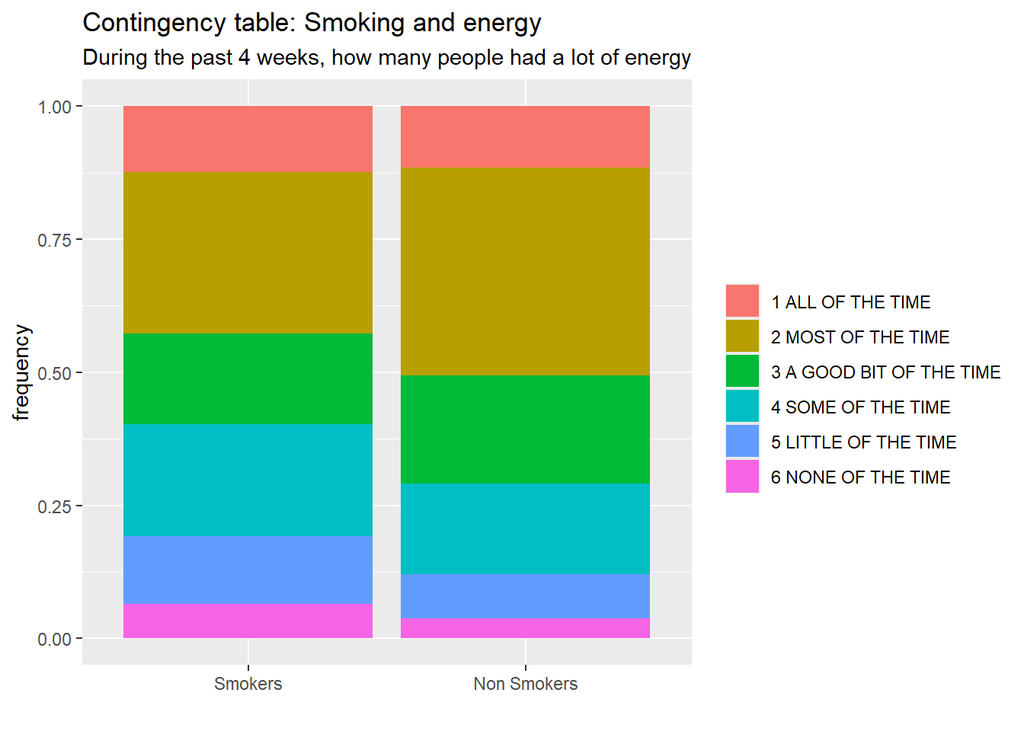

```r
#ADENGY42
table_multi_cat(small_df, "ADSMOK42", "ADENGY42") %>% as_tibble() %>%
  ggplot() + geom_col(aes(x = ADSMOK42, y = n, fill = ADENGY42)) +
  labs(subtitle = "During the past 4 weeks, how many people had a lot of energy",
       title = "Contingency table: Smoking and energy", x = "",
       y="frequency", fill="") +
  scale_x_discrete(labels = c("1 YES" = "Smokers",
                              "2 NO" = "Non Smokers"))
```

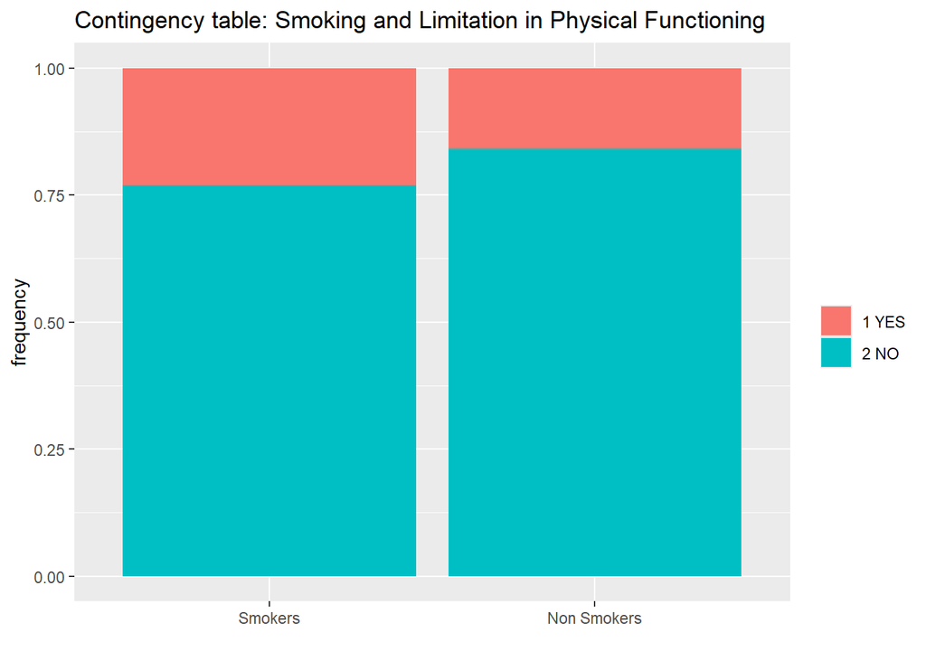

```r
#WLKLIM53

table_multi_cat(small_df, "ADSMOK42", "WLKLIM53") %>% as_tibble() %>%
  ggplot() + geom_col(aes(x = ADSMOK42, y = n, fill = WLKLIM53)) +
  labs(title = "Contingency table: Smoking and Limitation in Physical Functioning", x = "",
       y="frequency", fill="") +
  scale_x_discrete(labels = c("1 YES" = "Smokers",
                              "2 NO" = "Non Smokers"))
```

We see what we were expecting: the general health of smokers is worse. Non-Smokers are healthier, feel healthier and have more energy. We also see that among smokers there is a much higher rate of limitation in physical functioning. It’s hard to look for a direct causality between the two: there are many interactions between different demographic factors. We can explore this deeper, we will look at this association in different age groups.

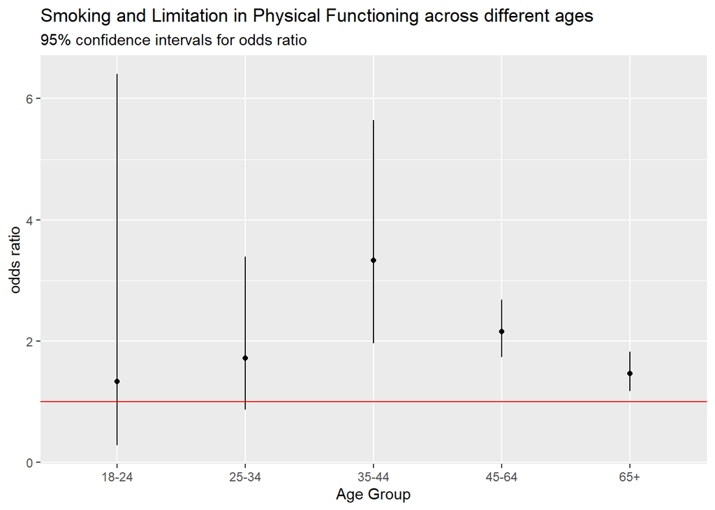

```r
# odds ratio: smoking and walking limitations in different age groups

table_multi_cat_control = function(data, explanatory_var, var_of_interest, cond_prob = T){
  tbl = data %>%
    select(explanatory_var, var_of_interest,age_group)%>%
    filter(.data[[explanatory_var]] %in% c("1 YES", "2 NO"),
           !.data[[var_of_interest]] %in% c("-15 CANNOT BE COMPUTED",
                                            "-1 INAPPLICABLE",
                                            "-8 DK","-7 REFUSED"))%>%
    mutate(across(c(1,2), factor)) %>%
    table()
  if (cond_prob){
    tbl = tbl %>% prop.table(margin = 1)
  }
  tbl
}



table_multi_cat_control(small_df, "ADSMOK42", "WLKLIM53",F) %>% as_tibble() %>%
  filter(age_group != "0-18") %>%
  group_by(age_group) %>%
  summarise(or_estimate = epitools::oddsratio(n,method = "wald",
                                              correction = F)$measure[2,"estimate"],
            or_lower = epitools::oddsratio(n,method = "wald",
                                              correction = F)$measure[2,"lower"],
            or_upper = epitools::oddsratio(n,method = "wald",
                                              correction = F)$measure[2,"upper"]) %>%
  mutate(age_group = factor(age_group)) %>%
  ggplot() +
  geom_point(aes(x = age_group, y = or_estimate)) +
  geom_segment(aes(x = age_group,xend=age_group,
                   y = or_lower, yend=or_upper))+
  geom_hline(aes(yintercept =1), col = "red") +
  labs(title = "Smoking and Limitation in Physical Functioning across different ages",
       subtitle = "95% confidence intervals for odds ratio",
       x = "Age Group",
       y="odds ratio")
```

This is an interesting graph: young people (under 35) tend to have good general health indicators regardless of their smoking habits. This changes as people start to age past that threshold. The next two age groups show a larger association between smoking and worse health than the oldest group. Is this suggesting that smoking makes the effects of aging start sooner? However once people reach old age, their health gets worse even if they don’t smoke.

## 3.2 Contingency tables for electronic nicotine product

### 3.2.1 Diseases Diagnosis

```r
# diseases association with electronic nicotine product
for(variable in health_disease_variables){
  if("1 YES" %in% levels(small_df[[variable]])){
  print(titles_health_disease[variable])
  print("Contingency table")
  print(cont_tables(small_df, "SDENICPROD", variable)%>% round(digits=3))
  print("testing hypothesis of no association")
  print(cont_tables(small_df, "SDENICPROD", variable,F)%>% chisq.test(correct = F))
  print("------------")
  }

}
```

```
##             ASTHDX
## "Asthma Diagnosis"
## [1] "Contingency table"
##           ASTHDX
## SDENICPROD 1 YES  2 NO
##      1 YES 0.201 0.799
##      2 NO  0.144 0.856
## [1] "testing hypothesis of no association"
##
##  Pearson's Chi-squared test
##
## data:  .
## X-squared = 52.75, df = 1, p-value = 3.788e-13
##
## [1] "------------"
##                ARTHDX
## "Arthritis Diagnosis"
## [1] "Contingency table"
##           ARTHDX
## SDENICPROD 1 YES  2 NO
##      1 YES 0.251 0.749
##      2 NO  0.331 0.669
## [1] "testing hypothesis of no association"
##
##  Pearson's Chi-squared test
##
## data:  .
## X-squared = 61.669, df = 1, p-value = 4.064e-15
##
## [1] "------------"
##                  CALUNG
## "Lung Cancer Diagnosis"
## [1] "Contingency table"
##           CALUNG
## SDENICPROD 1 YES  2 NO
##      1 YES 0.071 0.929
##      2 NO  0.026 0.974
## [1] "testing hypothesis of no association"
##
##  Pearson's Chi-squared test
```

[output cut: 80 more lines]

```
##             STRKDX
## "Stroke Diagnosis"
## [1] "Contingency table"
##           STRKDX
## SDENICPROD 1 YES  2 NO
##      1 YES 0.039 0.961
##      2 NO  0.054 0.946
## [1] "testing hypothesis of no association"
##
##  Pearson's Chi-squared test
##
## data:  .
## X-squared = 9.7534, df = 1, p-value = 0.00179
##
## [1] "------------"
```

Association between usage of Electronic Nicotine product and diseases: analysis with conditional contingency tables and chi squared tests Summary of key points:

- Asthma: strong association: who uses e cigs is more likely to have asthma

-Arthritis: strong association but in the opposite direction: who uses e-cigs has a lower rate of Arthritis. Probably because of confounding effect of age. Young people are less likely to have Arthritis, but are much more likely to use e cigs

-Lung Cancer: strong association, correct direction

-Cholesterol: strong association, but in opposite direction: need to control for age like arthritis

-Chronic Bronchitis: strong association, correct direction

-Emphysema: strong association, correct direction

-High Blood Pressure: strong association, but in opposite direction: need to control for age like arthritis

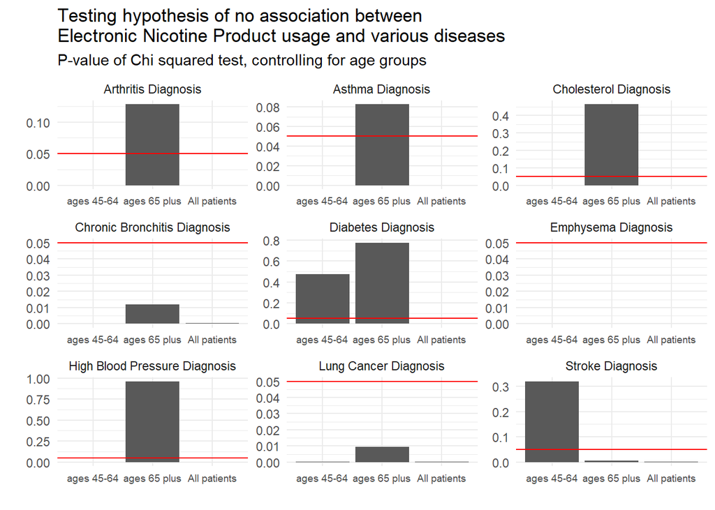

```r
# I don't like this plot anymore, showing the p-value makes almost no sense
# it made sense for ADSMOK42 because smokers always had higher rates than non smokers
# however for SDENICPROD for some diseases users have lower rates than non users
# so I will try to plot the odds ratio instead, which will let us see in which direction
# there is association -Giuseppe
chisq_df_diseases = data.frame(diseases = health_disease_variables,
                               p_val_full_data= rep(NA, length(health_disease_variables)),
                               p_val_65plus_data= rep(NA, length(health_disease_variables)),
                               p_val_45_64_data= rep(NA, length(health_disease_variables)))

for(i in 1:nrow(chisq_df_diseases)){
  variable = chisq_df_diseases[i,"diseases"]
  test_full = cont_tables(small_df,"SDENICPROD",variable, F) %>%
    chisq.test(correct = F)
  test_45_64 = cont_tables_age(small_df,"SDENICPROD",variable,"45-64",F) %>%
    chisq.test(correct = F)
  test_65plus = cont_tables_age(small_df,"SDENICPROD",variable,"65+",F) %>%
    chisq.test(correct = F)
  chisq_df_diseases[i,"p_val_full_data"] = test_full$p.val
  chisq_df_diseases[i,"p_val_45_64_data"] = test_45_64$p.val
  chisq_df_diseases[i,"p_val_65plus_data"] = test_65plus$p.val

}
chisq_df_diseases = chisq_df_diseases %>%
  rename(full_data = p_val_full_data,
         age_65plus = p_val_65plus_data,
         age_45_64 = p_val_45_64_data) %>%
  mutate(diseases = titles_health_disease[diseases]) %>%
  pivot_longer(cols=c("full_data","age_65plus","age_45_64"))

ggplot(chisq_df_diseases, aes(x = name, y = value)) +
  geom_col() + geom_hline(aes(yintercept = 0.05), col = "red") +
  facet_wrap(~diseases, scales = "free") +
  labs(title="Testing hypothesis of no association between
Electronic Nicotine Product usage and various diseases",
       subtitle = "P-value of Chi squared test, controlling for age groups",
       x = "", y ="")+
  scale_x_discrete(labels = c("full_data" = "All patients",
                              "age_65plus" = "ages 65 plus" ,
                              "age_45_64" = "ages 45-64")) +
  theme_minimal() + theme(axis.text.x = element_text(size = 7))
```

```r
#odds ratio
#odds of diseases for users/ odds of diseases for non users

or_data_all = expand.grid(diseases = health_disease_variables,
                      age = "all",estimate = NA,
                      lower = NA, upper = NA)

for(i in 1:nrow(or_data_all)){
  var_of_interest = as.character(or_data_all$diseases[i])
  or = small_df %>%
    select(SDENICPROD,var_of_interest)%>%
    filter(SDENICPROD %in% c("1 YES", "2 NO"),
           .data[[var_of_interest]] %in% c("1 YES", "2 NO")) %>%
    mutate(across(c(1,2), factor)) %>%
    table() %>% epitools::oddsratio(method = "wald", correction = F)
  or_data_all[i,"estimate"] = or$measure[2,"estimate"]
  or_data_all[i,"lower"] = or$measure[2,"lower"]
  or_data_all[i,"upper"] = or$measure[2,"upper"]
}

or_data_45_64 = expand.grid(diseases = health_disease_variables,
                      age = "45_64",estimate = NA,
                      lower = NA, upper = NA)

for(i in 1:nrow(or_data_45_64)){
  var_of_interest = as.character(or_data_45_64$diseases[i])
  or = small_df %>% filter(age_group == "45-64") %>%
    select(SDENICPROD,var_of_interest)%>%
    filter(SDENICPROD %in% c("1 YES", "2 NO"),
           .data[[var_of_interest]] %in% c("1 YES", "2 NO")) %>%
    mutate(across(c(1,2), factor)) %>%
    table() %>% epitools::oddsratio(method = "wald", correction = F)
  or_data_45_64[i,"estimate"] = or$measure[2,"estimate"]
  or_data_45_64[i,"lower"] = or$measure[2,"lower"]
  or_data_45_64[i,"upper"] = or$measure[2,"upper"]
}
or_data_65plus = expand.grid(diseases = health_disease_variables,
                      age = "65plus",estimate = NA,
                      lower = NA, upper = NA)

for(i in 1:nrow(or_data_65plus)){
  var_of_interest = as.character(or_data_65plus$diseases[i])
  or = small_df %>% filter(age_group == "65+") %>%
    select(SDENICPROD,var_of_interest)%>%
    filter(SDENICPROD %in% c("1 YES", "2 NO"),
           .data[[var_of_interest]] %in% c("1 YES", "2 NO")) %>%
    mutate(across(c(1,2), factor)) %>%
    table() %>% epitools::oddsratio(method = "wald", correction = F)
  or_data_65plus[i,"estimate"] = or$measure[2,"estimate"]
  or_data_65plus[i,"lower"] = or$measure[2,"lower"]
  or_data_65plus[i,"upper"] = or$measure[2,"upper"]
}
```

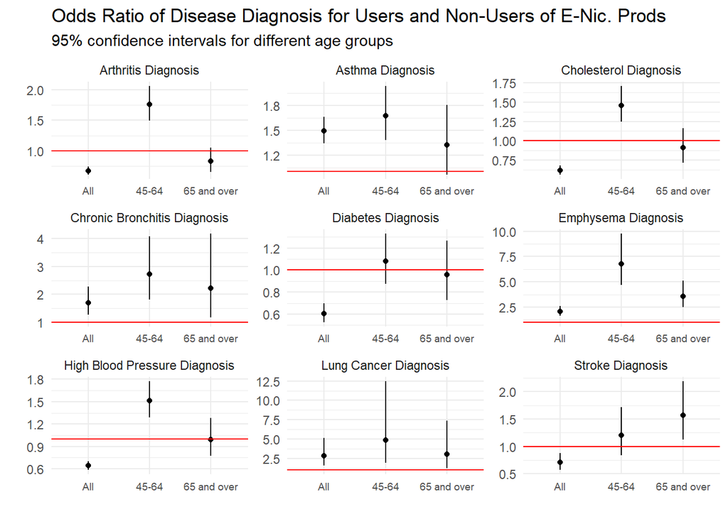

```r
or_data = rbind(or_data_all,or_data_45_64,or_data_65plus)

or_data %>% mutate(diseases = titles_health_disease[diseases]) %>%
  ggplot(aes(x = age)) + geom_point(aes(y = estimate)) +
  geom_segment(aes(x = age, xend = age, y = lower, yend = upper))+
  geom_hline(aes(yintercept  = 1), col = "red")+
  facet_wrap(~diseases, scales = "free") +
  labs(title="Odds Ratio of Disease Diagnosis for Users and Non-Users of E-Nic. Prods",
       subtitle = "95% confidence intervals for different age groups",
       x = "", y ="")+
  scale_x_discrete(labels = c("all" = "All",
                              "65plus" = "65 and over" ,
                              "45_64" = "45-64")) +
  theme_minimal() + theme(axis.text.x = element_text(size = 7))
```

### 3.2.2 General Health

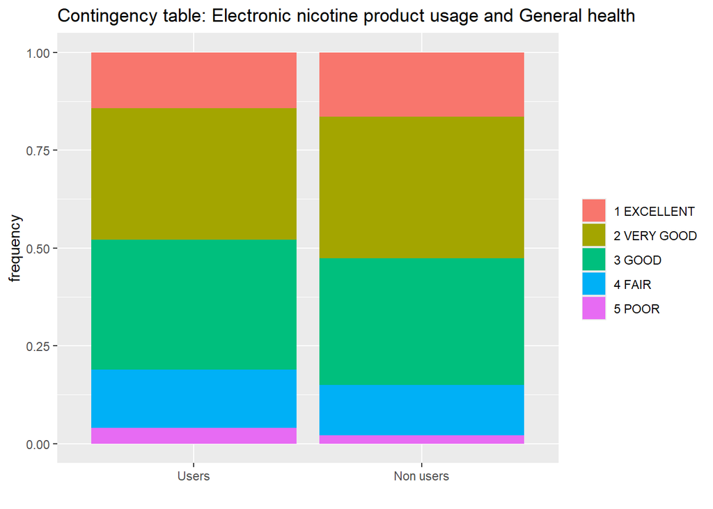

```r
#ADGENH42
table_multi_cat(small_df, "SDENICPROD", "ADGENH42") %>% as_tibble() %>%
  ggplot() + geom_col(aes(x = SDENICPROD, y = n, fill = ADGENH42)) +
  labs(title = "Contingency table: Electronic nicotine product usage and General health", x = "",
       y="frequency", fill="") +
  scale_x_discrete(labels = c("1 YES" = "Users",
                              "2 NO" = "Non users"))
```

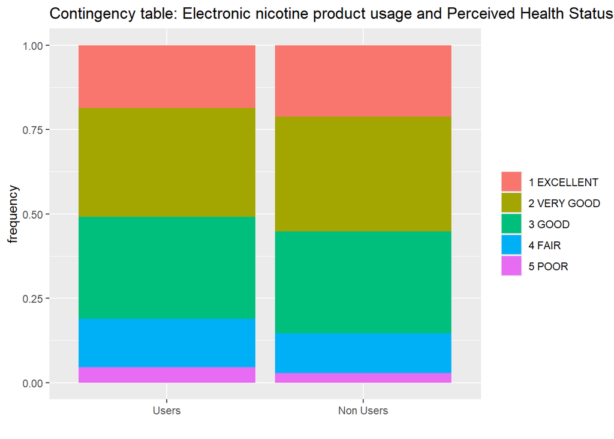

```r
#RTHLTH31
table_multi_cat(small_df, "SDENICPROD", "RTHLTH31") %>% as_tibble() %>%
  ggplot() + geom_col(aes(x = SDENICPROD, y = n, fill = RTHLTH31)) +
  labs(title = "Contingency table: Electronic nicotine product usage and Perceived Health Status", x = "",
       y="frequency", fill="") +
  scale_x_discrete(labels = c("1 YES" = "Users",
                              "2 NO" = "Non Users"))
```

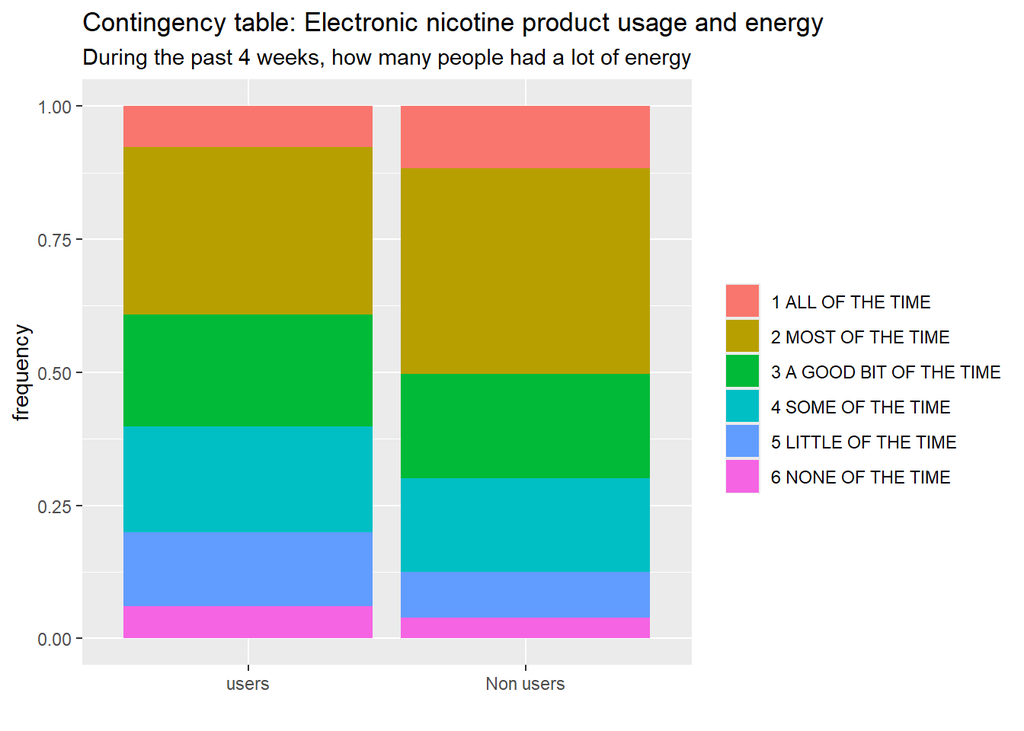

```r
#ADENGY42
table_multi_cat(small_df, "SDENICPROD", "ADENGY42") %>% as_tibble() %>%
  ggplot() + geom_col(aes(x = SDENICPROD, y = n, fill = ADENGY42)) +
  labs(subtitle = "During the past 4 weeks, how many people had a lot of energy",
       title = "Contingency table: Electronic nicotine product usage and energy", x = "",
       y="frequency", fill="") +
  scale_x_discrete(labels = c("1 YES" = "users",
                              "2 NO" = "Non users"))
```

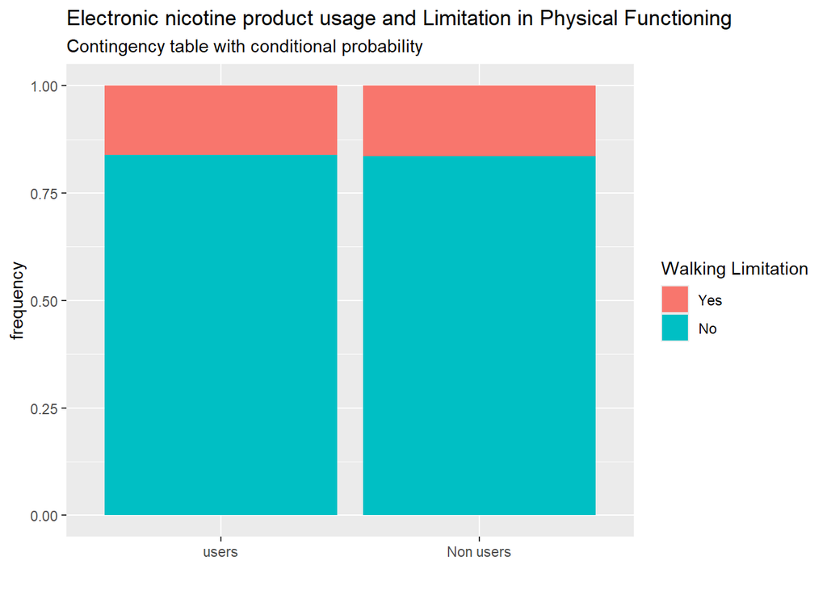

```r
#WLKLIM53

table_multi_cat(small_df, "SDENICPROD", "WLKLIM53") %>% as_tibble() %>%
  ggplot() + geom_col(aes(x = SDENICPROD, y = n, fill = WLKLIM53)) +
  labs(title = "Electronic nicotine product usage and Limitation in Physical Functioning",
       subtitle = "Contingency table with conditional probability",
       x = "",
       y="frequency", fill="Walking Limitation") +
  scale_x_discrete(labels = c("1 YES" = "users",
                              "2 NO" = "Non users"))+
  scale_fill_discrete(labels = c("Yes", "No"))
```

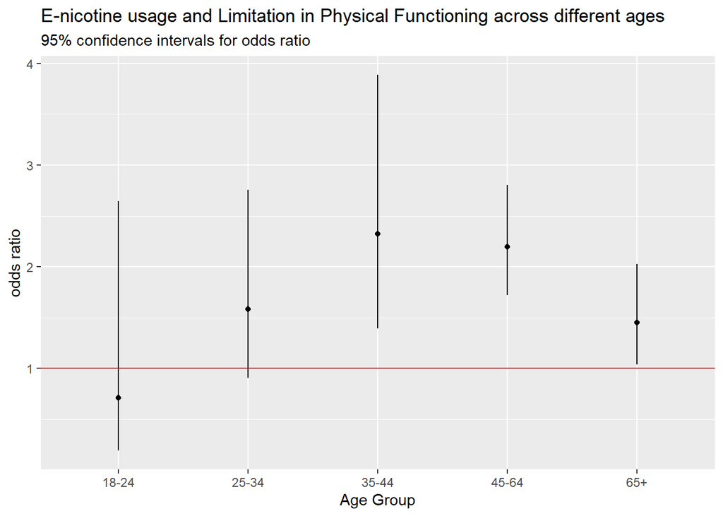

```r
# odds ratio: E-nic usage and walking limitations in different age groups

table_multi_cat_control(small_df, "SDENICPROD", "WLKLIM53",F) %>% as_tibble() %>%
  filter(age_group != "0-18") %>%
  group_by(age_group) %>%
  summarise(or_estimate = epitools::oddsratio(n,method = "wald",
                                              correction = F)$measure[2,"estimate"],
            or_lower = epitools::oddsratio(n,method = "wald",
                                              correction = F)$measure[2,"lower"],
            or_upper = epitools::oddsratio(n,method = "wald",
                                              correction = F)$measure[2,"upper"]) %>%
  mutate(age_group = factor(age_group)) %>%
  ggplot() +
  geom_point(aes(x = age_group, y = or_estimate)) +
  geom_segment(aes(x = age_group,xend=age_group,
                   y = or_lower, yend=or_upper))+
  geom_hline(aes(yintercept =1), col = "red") +
  labs(title = "E-nicotine usage and Limitation in Physical Functioning across different ages",
       subtitle = "95% confidence intervals for odds ratio",
       x = "Age Group",
       y="odds ratio")
```

### 3.2.3 Mental health

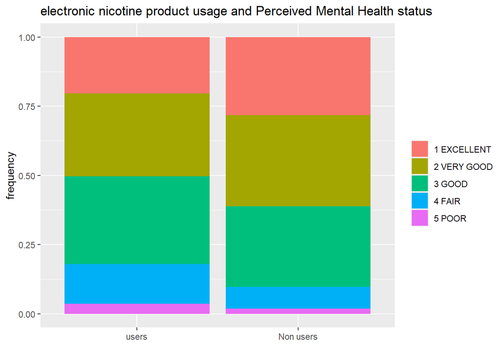

```r
# "MNHLTH31"
table_multi_cat(small_df, "SDENICPROD", "MNHLTH31") %>% as_tibble() %>%
  ggplot() + geom_col(aes(x = SDENICPROD, y = n, fill = MNHLTH31)) +
  labs(title = "electronic nicotine product usage and Perceived Mental Health status", x = "",
       y="frequency", fill="") +
  scale_x_discrete(labels = c("1 YES" = "users",
                              "2 NO" = "Non users"))
```

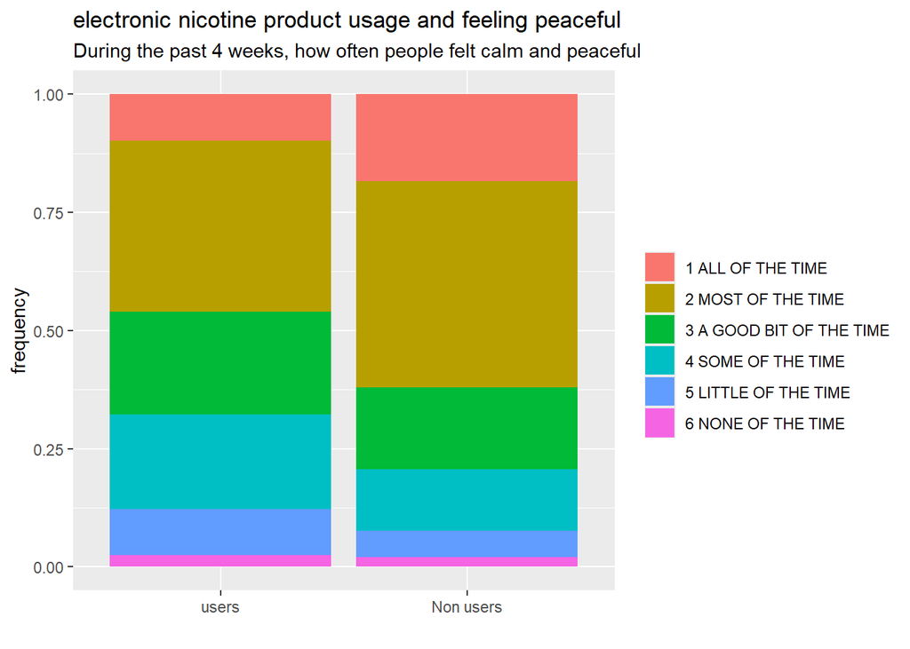

```r
#"ADPCFL42"
table_multi_cat(small_df, "SDENICPROD", "ADPCFL42") %>% as_tibble() %>%
  ggplot() + geom_col(aes(x = SDENICPROD, y = n, fill = ADPCFL42)) +
  labs(subtitle = "During the past 4 weeks, how often people felt calm and peaceful",
       title = "electronic nicotine product usage and feeling peaceful", x = "",
       y="frequency", fill="") +
  scale_x_discrete(labels = c("1 YES" = "users",
                              "2 NO" = "Non users"))
```

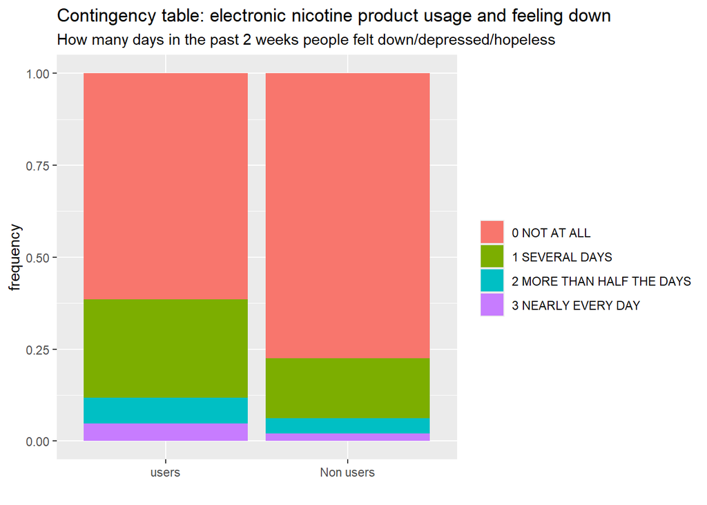

```r
#"ADDPRS42"
table_multi_cat(small_df, "SDENICPROD", "ADDPRS42") %>% as_tibble() %>%
  ggplot() + geom_col(aes(x = SDENICPROD, y = n, fill = ADDPRS42)) +
  labs(subtitle = "How many days in the past 2 weeks people felt down/depressed/hopeless",
       title = "Contingency table: electronic nicotine product usage and feeling down", x = "",
       y="frequency", fill="") +
  scale_x_discrete(labels = c("1 YES" = "users",
                              "2 NO" = "Non users"))
```

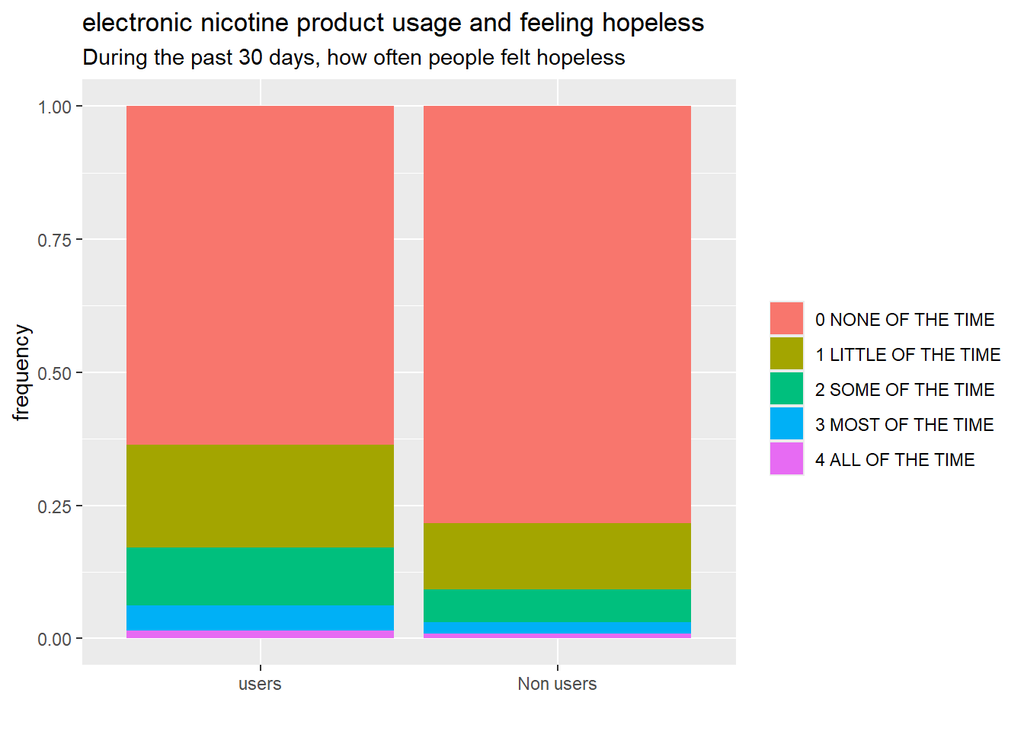

```r
# "ADHOPE42"
table_multi_cat(small_df, "SDENICPROD", "ADHOPE42") %>% as_tibble() %>%
  ggplot() + geom_col(aes(x = SDENICPROD, y = n, fill = ADHOPE42)) +
  labs(subtitle = "During the past 30 days, how often people felt hopeless",
       title = "electronic nicotine product usage and feeling hopeless", x = "",
       y="frequency", fill="") +
  scale_x_discrete(labels = c("1 YES" = "users",
                              "2 NO" = "Non users"))
```

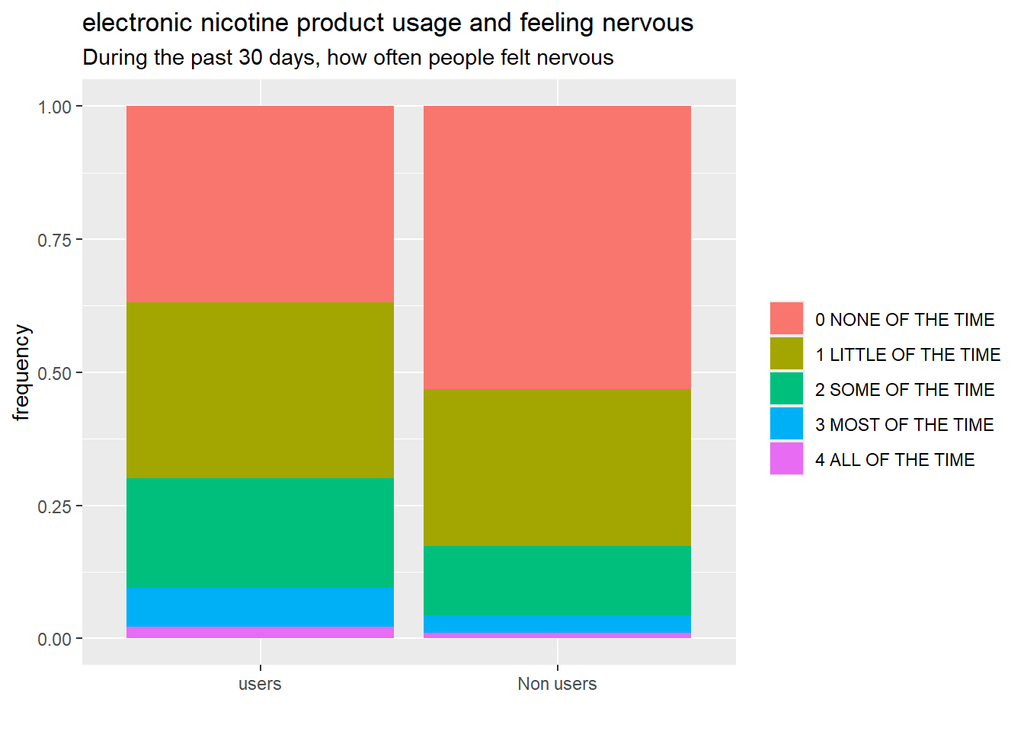

```r
# "ADNERV42"
table_multi_cat(small_df, "SDENICPROD", "ADNERV42") %>% as_tibble() %>%
  ggplot() + geom_col(aes(x = SDENICPROD, y = n, fill = ADNERV42)) +
  labs(subtitle = "During the past 30 days, how often people felt nervous",
       title = "electronic nicotine product usage and feeling nervous", x = "",
       y="frequency", fill="") +
  scale_x_discrete(labels = c("1 YES" = "users",
                              "2 NO" = "Non users"))
```

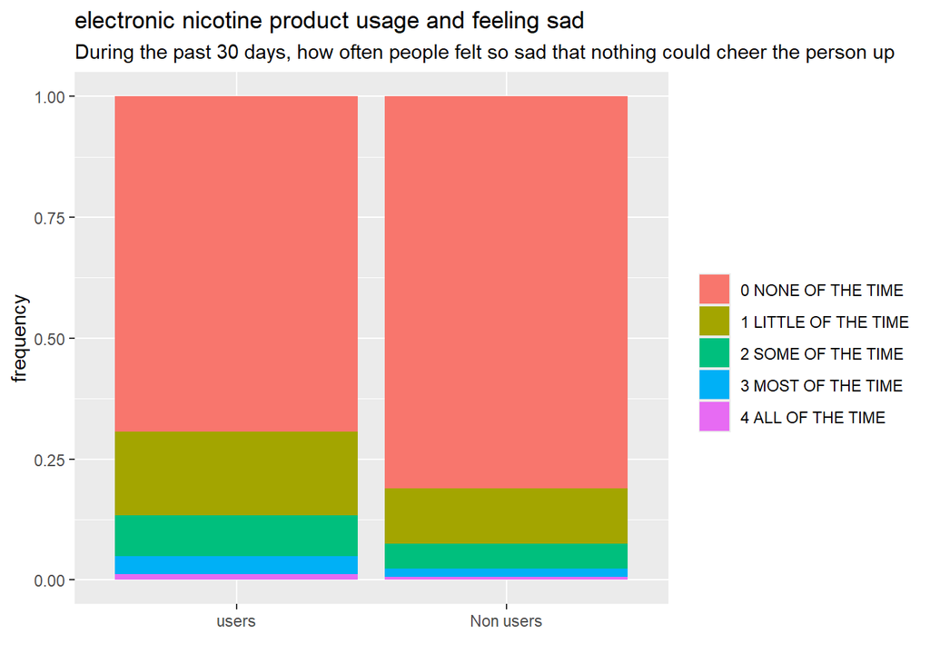

```r
# "ADSAD42"
table_multi_cat(small_df, "SDENICPROD", "ADSAD42") %>% as_tibble() %>%
  ggplot() + geom_col(aes(x = SDENICPROD, y = n, fill = ADSAD42)) +
  labs(subtitle = "During the past 30 days, how often people felt so sad that nothing could cheer the person up",
       title = "electronic nicotine product usage and feeling sad", x = "",
       y="frequency", fill="") +
  scale_x_discrete(labels = c("1 YES" = "users",
                              "2 NO" = "Non users"))
```

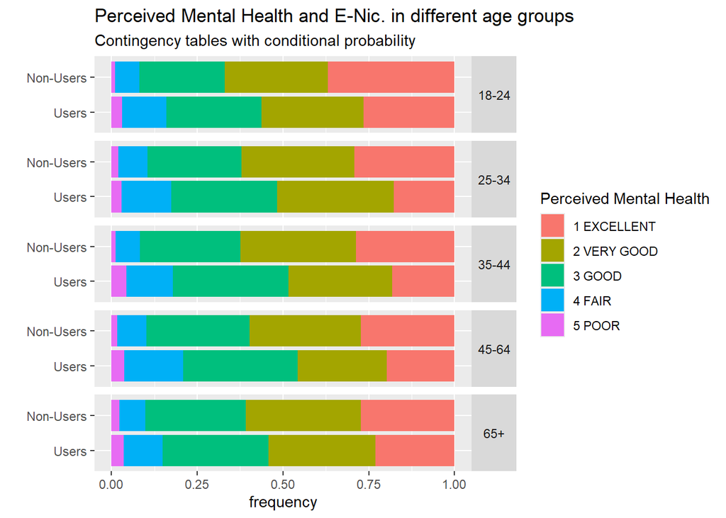

```r
# mental health controlling for age

# looking at how the contingency table for perceived mental health and e-nic. usage
# is different in the different age groups
age_18_24 = table_multi_cat_age(small_df, "SDENICPROD", "MNHLTH31", "18-24") %>% as_tibble %>%
  mutate(age = "18-24")
age_25_34 = table_multi_cat_age(small_df, "SDENICPROD", "MNHLTH31", "25-34") %>% as_tibble %>%
  mutate(age = "25-34")
age_35_44 = table_multi_cat_age(small_df, "SDENICPROD", "MNHLTH31", "35-44") %>% as_tibble %>%
  mutate(age = "35-44")
age_45_64 = table_multi_cat_age(small_df, "SDENICPROD", "MNHLTH31", "45-64") %>% as_tibble %>%
  mutate(age = "45-64")
age_65plus = table_multi_cat_age(small_df, "SDENICPROD", "MNHLTH31", "65+") %>% as_tibble %>%
  mutate(age = "65+")

all_tables = rbind(age_18_24,age_25_34,age_35_44,age_45_64,age_65plus)

all_tables %>% mutate(age = factor(age)) %>%
  ggplot(aes(x = n, fill = MNHLTH31, y = SDENICPROD)) +
  geom_col(orientation = "y") +
  facet_grid(rows = vars(age))+
  labs(title = "Perceived Mental Health and E-Nic. in different age groups", y = "",
       subtitle = "Contingency tables with conditional probability", x="frequency", fill="Perceived Mental Health") +
  scale_y_discrete(labels = c("1 YES" = "Users",
                              "2 NO" = "Non-Users"))+
  theme(strip.text.y = element_text(angle = 0))
```

Summary:

the general health of e-nicotine products users is the not much lower than that of non users. However there is a bigger gap in the mental health of the two groups: in the data we see that non users tend to have higher values of good mental health